# Gene Expression Analysis

Finn

24 October 2021

# 1 All Data we have on Gene Expression

If I am not mistaken, we have 2 separate people that worked on gene expression in the past:

- Svenja collected data with RTqPCR in 2016/17 for 88 samples (AA_0053 - AA_0465)
- Luke ran RTqPCRs again in 2021 for 327 samples, including all of Svenja’s samples as well (AA_0053 - AA_0853)

## 1.1 Housekeeping Genes

Housekeeping genes are generally used to differentiate actual immune response to a stimulus (in our case infections with parasites) from normal gene expression. Expression of HK genes is constant in natural and stimulated state.

- Svenja used:
  - B.Actin ( *actb* in literature I have seen)
  - GAPDH
- Luke used:
  - PPIB
  - GAPDH

Since Luke redid all the samples and the protocol included pre-amplification, the results from Svenja are not comparable to Luke’s. Therefore, only results from Luke will be used for further analysis.

Samples lost in Luke’s IFC run: - AA_0072 - AA_00432

## 1.2 Use of HK genes

1. build the geometric mean of all GAPDH values from all samples with *psych* package `GAPDH_Norm = geometric.mean(SOTA$GAPDH, na.rm = TRUE)`
2. subtract immuno gene values from the Norm

   `Normalized_Value = GAPDH_Norm - Immuno_Gene`

## 1.3 Immune Response Genes of Interest (GOI)

| Name | Full_Name_Info | Function | Definition |
| --- | --- | --- | --- |
| B-actin | Beta-Actin | HKG | nonmuscle cytoskeletal actin, involved in cell motility, structure and integrity |
| CASP1 | Caspase-1 | inflammasome marker (IL-1b and IL-18 production) | Caspase-1/Interleukin-1 converting enzyme is an evolutionarily conserved enzyme that proteolytically cleaves other proteins |
| CD56 |  | CD56bright = more cytokine producing NKs, CD56dim = more direct cytotoxic killing | cell surface glycoprotein |
| CDC42 | Cell division control protein 42 homolog | HKG | protein involved in regulation of the cell cycle |
| CXCL9 | Chemokine ligand 9 | immune cell migration marker + Th1 activator | binds to CXCR3 and primarily attracts activated T lymphocytes |
| CXCR3 | Chemokine receptor | CXCL9 and CXCL11 receptor | important role in T cell trafficking and function |
| GAPDH | Glyceraldehyde 3-phosphate dehydrogenase | HKG | enzyme for energy metabolism and the production of ATP and pyruvate |
| IDO1 | Indoleamine-pyrrole 2,3-dioxygenase | DC, monocyte and MC protein regulating T-cell activity | capable of modulating immune cell activation status and phenotype |
| IFNy | Interferon Gamma | compare with IFN-y producing cells and IFN-y ELISAs, should correlate wit PRF1, NKp46 and F4/80. One of these cell types just have to be doing the job! | important activator of macrophages and inducer of major histocompatibility complex class II molecule expression |
| IL-10 | Interleukin-10 |  | cytokine synthesis inhibitory factor, an anti-inflammatory cytokine |
| IL-12ra | Interleukin-12 | T-cell marker Th1 | effective in combatting a wide range of naturally occurring viral infections through the upregulation of various cytokines |
| IL-13 | Interleukin-13 |  | produced by Th2 cells, natural killer T cell |
| IL-17 | Interleukin-17 | in case IFN-y isn’t coming up but pathogenicity is | pro-inflammatory cystine knot cytokine |
| IL-1Ra | Interleukin-1 receptor antagonist | natuaral IL-1b antagonist for infection control (if not increase in Tregs is seen) |  |
| IL-4 | Interleukin-4 |  | induces differentiation of naive helper T cells to Th2 cells |
| IL-6 | Interleukin-6 | TNF inhibitor | acts as both a pro-inflammatory cytokine and an anti-inflammatory myokine |
| IRG6A | Immunoglobulin A | autonomous cell defense (opsonization) | antibody that plays a crucial role in the immune function of mucous membranes |
| Mpo | Myeloperoxidase | myeloperoxidase in Neutrophils | most abundantly expressed in neutrophil granulocytes, and produces hypohalous acids to carry out their antimicrobial activit |
| Muc2 | Mucin-2 | the major secretory mucin within the gastrointestinal tract | Coats the epithelia of the intestines, airways, and other mucus membrane-containing organs |
| Muc5ac | Mucin-5AC | similar to MUC2, produced by surface goblet cells | Gel-forming glycoprotein of gastric and respiratory tract epithelia |
| MyD88 | Myeloid differentiation primary response 88 | TLR protein, NF-kB IRAK protein, inflammation marker by TLR | canonical adaptor for inflammatory signaling pathways downstream of members of the Toll-like receptor (TLR) and interleukin-1 (IL-1) receptor families |
| NKp46 | Natural Killer cell p46 | NK marker | innate lymphocytes that efficiently eliminate cancerous and infected cells |
| PPIA | Peptidylprolyl isomerase A | HKG | catalyzes the cis-trans isomerization of proline imidic peptide bonds, which allows it to regulate many biological processes, including intracellular signaling, transcription, inflammation, and apopto… |
| PPIB | Peptidyl-prolyl cis-trans isomerase B | HKG | catalyzes the cis-trans isomerization of proline imidic peptide bonds, which allows it to regulate protein folding of type I collagen |
| Prf1 | Perforin-1 | perforin, should be dominant in primary infections, but must be correlated between T-cell and NK cell expresions | Pore-forming protein that plays a key role in secretory granule-dependent cell death, and in defense against virus-infected or neoplastic cells |
| Relm-b | Resistin-like molecule-β | mucosal defense factor (goblet cells) | cysteine-rich cytokine expressed in the gastrointestinal tract and implicated in insulin resistance and gastrointestinal nematode immunity |
| Socs1 | Suppressors of Cytokine Signaling | JAK/STAT signaling pathway, proinflammatory regulating + T-cell differentiation, could explain severity | SOCS-1 regulates responses to IL-12 in mice |
| TFF3 | Trefoil factor 3 | mucosal defense factor (goblet cells) | stable secretory protein expressed in the goblet cells of the gastrointestinal mucosa |
| TNF-a | Tumour Necrosis Factor alpha | upregulated in eimeria but not well explained. Could be present and driving infection where IFN-y isn’t | inflammatory cytokine produced by macrophages/monocytes during acute inflammation |
| TRIF | TIR domain-containing adaptor-inducing interferon-β | Type I IFN production | cytosolic adaptor protein, plays a key role in the mammalian toll-like receptor-mediated signaling pathway |

# 2 Table of normalized Gene Expression Values

| Mouse_ID | CASP1 | CXCL9 | CXCR3 | GAPDH | IDO1 | IFNy | IL.10 | IL.13 | IL1RN | IRGM1 | MPO | MUC2 | MUC5AC | MYD88 | NCR1 | PPIB | PRF1 | RETNLB | SOCS1 | TICAM1 | TNF | IL.6 |
| --- | --- | --- | --- | --- | --- | --- | --- | --- | --- | --- | --- | --- | --- | --- | --- | --- | --- | --- | --- | --- | --- | --- |
| AA_0053 | -16.80512 | -9.918655 | -14.86632 | 3.925677 | -6.749920 | -12.17933 | -14.38602 | -11.707806 | -5.222227 | -3.887694 | -10.178511 | -2.5583908 | -2.494919 | -7.839956 | -19.95560 | 16.60248 | -16.31085 | -4.430020 | -4.928645 | -14.05986 | -12.47252 | NA |
| AA_0061 | NA | -18.961333 | -23.45499 | 4.550099 | -21.649782 | NA | NA | -8.236867 | -16.026603 | -4.312666 | -23.402207 | -3.0776868 | -14.962449 | -13.674364 | -22.69507 | NA | -16.60396 | NA | -4.759894 | -13.59767 | -23.07927 | -20.19429 |
| AA_0065 | -18.59887 | NA | -22.32337 | 4.506561 | -22.748976 | NA | -22.84322 | -23.205162 | -17.456124 | -4.814216 | NA | -16.7162876 | -15.868547 | NA | NA | 23.80159 | NA | -17.558653 | -4.911548 | NA | -22.21630 | NA |
| AA_0067 | -14.14004 | -14.671732 | -14.03573 | 3.121567 | -10.811921 | -16.10497 | -20.01156 | -14.844900 | -8.984768 | -3.044166 | -9.876203 | -1.5922716 | -1.729695 | -2.475558 | -20.66533 | 18.63057 | -20.95625 | -3.741285 | -4.057484 | -18.57062 | -13.87404 | -19.27772 |
| AA_0078 | -14.42411 | -12.498125 | -14.13797 | 4.297649 | -6.768310 | -14.80708 | -15.39996 | -9.327553 | -5.600731 | -4.327545 | -10.586733 | -2.8074851 | -2.890711 | -3.621633 | -23.57602 | 12.76778 | -21.18858 | -3.978496 | -5.498129 | -10.18456 | -12.85645 | -17.98724 |
| AA_0079 | NA | NA | NA | 16.756945 | NA | NA | NA | NA | NA | -17.016585 | NA | -16.8750190 | -17.310917 | -17.641638 | NA | NA | NA | -16.767655 | -19.225721 | NA | NA | NA |
| AA_0082 | -16.20999 | -8.080921 | -14.09222 | 3.914076 | -5.581882 | -11.43139 | -14.82060 | -11.074182 | -4.677948 | -3.658668 | -10.202863 | -2.3203225 | -2.347487 | -3.111642 | -20.08583 | 13.21014 | NA | -2.767547 | -4.626542 | -12.80703 | -14.54597 | -14.30738 |
| AA_0086 | NA | -14.113853 | -14.89529 | 5.810489 | -6.733754 | -13.11029 | NA | -5.185422 | -5.667944 | -5.889065 | -12.637847 | -4.1049525 | -4.297855 | -10.548483 | -17.04684 | NA | NA | NA | -7.050372 | -11.35785 | -15.07703 | -16.06406 |
| AA_0090 | NA | -17.844008 | -16.33775 | 5.240104 | -19.465495 | NA | NA | -4.804253 | NA | -5.505816 | -20.693051 | -4.0311965 | -4.151510 | -14.977859 | -22.24057 | NA | -22.20897 | NA | -6.800192 | -17.64887 | -19.37684 | NA |
| AA_0093 | NA | -14.216100 | -14.69308 | 4.624777 | -6.043639 | -18.52240 | NA | -3.859678 | -4.628795 | -4.512894 | -10.692251 | -3.0474015 | -3.037695 | -11.830765 | -20.42063 | NA | -17.53812 | NA | -5.480342 | -12.30691 | -15.82695 | -16.65571 |
| AA_0094 | -14.59920 | -9.350544 | -14.04873 | 2.773633 | -7.771685 | -12.49953 | -16.42262 | -12.076784 | -10.526187 | -2.816346 | -10.216952 | -1.2290042 | -1.331639 | -2.345889 | -19.99313 | 15.63577 | -22.92360 | -3.047526 | -3.906312 | -13.09857 | -13.99157 | -14.32732 |
| AA_0099 | NA | -11.426736 | -17.84569 | 5.787655 | -6.287597 | -12.11186 | NA | -5.094572 | -5.812971 | -6.074304 | -11.798312 | -4.2518212 | -4.323597 | -16.182442 | -17.82192 | NA | -17.10842 | NA | -6.550145 | NA | -16.24845 | NA |
| AA_0101 | -15.74983 | -14.219022 | -15.86532 | 3.563040 | -12.936790 | -15.68614 | -20.99813 | -13.853240 | -9.164053 | -3.511621 | -10.099482 | -1.9053994 | -2.073620 | -2.928981 | -20.52744 | 17.80185 | -20.74301 | -2.919657 | -5.003976 | -14.52719 | -12.49133 | -16.96837 |
| AA_0105 | NA | -17.619756 | -15.34005 | 4.901404 | -5.043551 | -10.21502 | NA | -3.988496 | -4.375626 | -5.218603 | -10.782210 | -3.1278415 | -3.110546 | -15.039502 | -20.06880 | NA | -20.54923 | NA | -5.809607 | -17.79795 | -16.75118 | -20.05409 |
| AA_0106 | NA | -15.364375 | -20.40788 | 5.059254 | -18.420633 | -21.75336 | NA | -14.946846 | -16.549932 | -4.983248 | -21.470317 | -15.4166788 | -16.334755 | -16.413014 | -20.89005 | NA | -16.57108 | NA | -4.990682 | -21.49714 | -21.87639 | NA |
| AA_0112 | -14.06616 | -10.231365 | -11.32608 | 2.500000 | -9.281993 | -17.83700 | -10.77209 | -8.388506 | -6.177721 | -1.807708 | -18.678669 | -1.6236271 | -7.984707 | -7.206998 | -18.63808 | 13.89132 | -16.14439 | -2.591790 | -3.693341 | -12.97620 | -7.13953 | -15.94372 |
| AA_0113 | -14.44855 | -9.942115 | -14.37720 | 2.500000 | -9.344076 | -13.29432 | -22.35868 | -15.096995 | -11.113891 | -2.446930 | -16.404849 | -0.8796900 | -1.712568 | -2.312664 | -20.68876 | 17.44207 | -20.43380 | -3.665878 | -3.231056 | -18.31053 | -17.21513 | -20.79723 |
| AA_0115 | NA | -16.457138 | -15.98282 | 4.425095 | -16.976010 | -20.50040 | NA | -3.393186 | -11.966176 | -4.070421 | -11.486966 | -2.2116871 | -2.356956 | -17.185955 | -20.09249 | NA | -17.46987 | NA | -4.437156 | -17.13409 | -16.54975 | -18.70196 |
| AA_0120 | -14.89301 | -14.457093 | -14.31627 | 4.046577 | -9.440383 | -15.77931 | -20.33353 | -17.620044 | -7.072299 | -4.205418 | -10.408845 | -2.4122188 | -2.532592 | -3.406259 | -19.76212 | 17.49239 | -18.33200 | -4.086086 | -4.992124 | -17.20181 | -15.13889 | -19.42553 |
| AA_0121 | -14.92653 | -13.789271 | -14.28389 | 3.724662 | -11.059510 | -16.11934 | -20.18857 | -13.887909 | -11.799474 | -3.720185 | -11.178049 | -1.9387447 | -2.176284 | -3.072884 | NA | 17.29094 | -20.58801 | -3.274266 | -4.530800 | -16.27683 | -14.51851 | -16.57232 |
| AA_0123 | -17.70888 | -14.008521 | -15.54641 | 4.251956 | -7.203019 | -15.76691 | -17.30666 | -11.433546 | -6.287862 | -4.568946 | -10.313146 | -3.2617875 | -3.265303 | -4.074316 | -20.25231 | 15.04650 | -18.03796 | -4.277358 | -5.677413 | -14.61593 | -14.40595 | -20.80277 |
| AA_0128 | NA | -16.521256 | -16.34707 | 5.022341 | -7.029643 | -16.71303 | NA | -5.162202 | -7.461511 | -5.508631 | -10.916616 | -4.0987433 | -3.911060 | -15.473078 | -20.04811 | NA | -16.51928 | NA | -6.194269 | -15.12840 | -20.15762 | -19.62658 |
| AA_0129 | NA | -12.735076 | -15.34620 | 4.330273 | -12.805644 | -21.31789 | NA | -3.343864 | -16.819436 | -3.852364 | -20.158839 | -2.4614577 | -4.233187 | -12.028755 | -18.54207 | NA | -16.52175 | NA | -4.427369 | -12.91289 | -16.25106 | -17.18841 |
| AA_0130 | NA | -14.306703 | -15.92826 | 4.906311 | -5.662919 | -18.04459 | NA | -3.746561 | -4.788180 | -5.062832 | -10.731409 | -3.3318012 | -3.347777 | -12.932647 | -18.66398 | NA | -15.75535 | NA | -5.830237 | -13.67138 | -15.60521 | -17.29771 |
| AA_0153 | -14.90997 | -8.001395 | -13.49805 | 2.500000 | -7.922780 | -14.22572 | -15.29394 | -9.926892 | -10.281660 | -2.520331 | -12.283366 | -0.7331122 | -1.361642 | -2.142501 | -16.50662 | 11.79259 | -18.98444 | 1.472782 | -3.346321 | -11.28554 | -13.22223 | -13.28471 |
| AA_0165 | -14.68208 | -10.528019 | -14.92016 | 3.097061 | -8.561498 | -15.50909 | -15.20320 | -13.073697 | -10.016286 | -3.016355 | -9.938910 | -1.4850433 | -1.655801 | -2.220686 | -17.26337 | 15.47232 | -18.81018 | -2.287863 | -3.933193 | -14.63764 | -14.04278 | -21.64381 |
| AA_0167 | -13.61833 | -8.428893 | -14.37152 | 2.500000 | -7.989777 | -14.21047 | -14.55318 | -10.005108 | -10.710975 | -2.353126 | -17.847216 | -0.7252177 | -1.326561 | -2.173314 | -20.65862 | 12.78446 | -15.32552 | -1.969319 | -3.230563 | -10.32514 | -12.45184 | NA |
| AA_0168 | -19.50198 | -9.570846 | -15.95179 | 3.744232 | -11.429531 | -13.24848 | -16.74867 | -12.752495 | -12.755750 | -3.813651 | -11.878036 | -2.0852060 | -2.217453 | -3.140326 | NA | 16.85201 | NA | -2.280351 | -4.436049 | -14.35239 | -15.17252 | -15.61142 |
| AA_0169 | -16.73994 | -16.548378 | -17.26543 | 9.959606 | -16.781184 | -19.76896 | -22.35382 | -17.863840 | -18.193493 | -9.690684 | -19.790176 | -14.9500277 | -16.837842 | -15.151162 | NA | 23.21211 | -20.33580 | -13.429975 | -13.165532 | -19.22316 | -23.19433 | NA |
| AA_0171 | NA | -14.193195 | -16.21023 | 3.815641 | -15.710028 | -17.23551 | NA | -2.525440 | -16.154766 | -3.017907 | -21.091735 | -1.2341161 | -2.253494 | -13.600478 | -18.17708 | NA | -21.39315 | NA | -3.688235 | -13.04243 | -16.42172 | -18.01829 |

# 3 Visualization of normalized Gene Expression Values vs. Infection Intensity

## 3.1 normalized Gene Expression Values vs. Infection Intensity

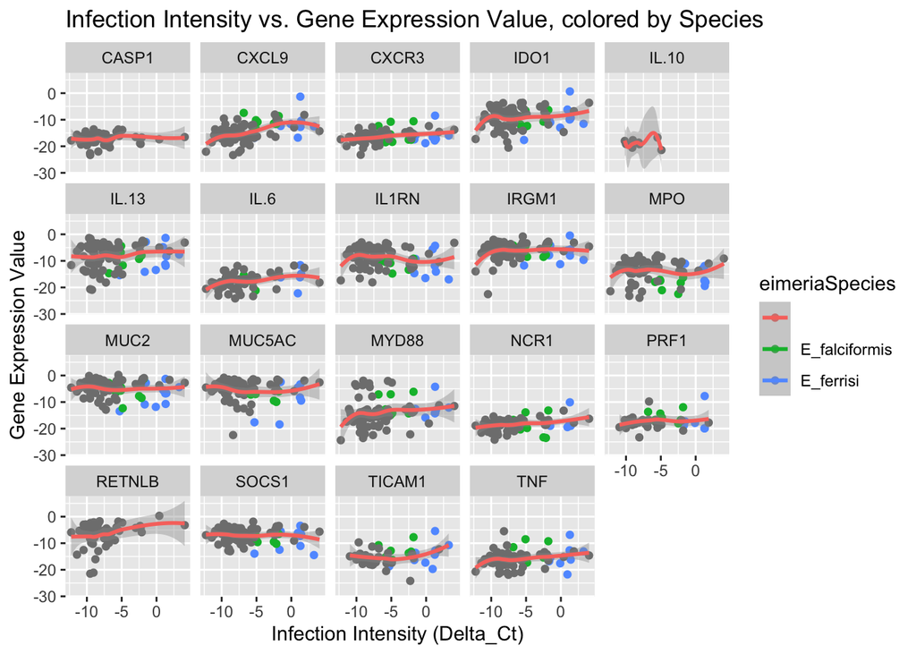

## 3.2 Same but with method == lm

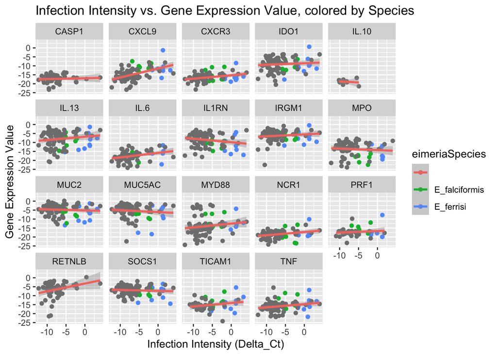

## 3.3 Gene Expression Values vs. HI

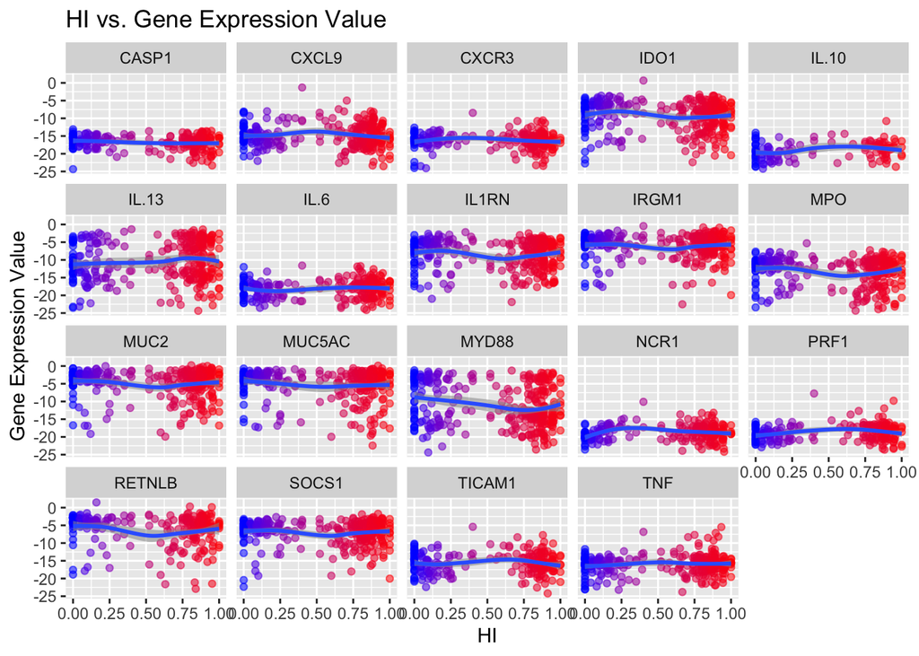